# Simulation and sampling variability

2020-10-19

## Course context

- In the previous class we used randomness in a simulation to investigate the alleged Hot-Hands phenomenon in basketball. We found that repeating simulations would be useful because of the variability in the simulation outcomes.
- If you repeat a simulation with built-in randomness to obtain a conclusion, then you are using the *Monte Carlo method*.
- Randomness provides a way to make samples created in the simulation representative, and to use them to draw conclusions about the population from which you are simulating/sampling.
- But how do we cope with the variability in our results that is due to randomness?

## Activity I

## Learning goals

- To practice implementing a simple simulation and to start thinking about its properties, in the R-prep material for today’s class you simulated sums of rolling two dice. This scenario was however so simple that we can undertand it easily without a simulation.
- In this activity we will consider a situation for which the mathematics quickly becomes so complex that a simulation is a better way forward.
- We will keep an eye on the variability our simulation results exhibit due to its in-build randomness, and see what happens to the variability when we run longer simulations.

## Birthday problem

In a group of 367 students, we can be certain that at least 2 students share the same birthday. (*Pigeon hole principle*)

How big is the chance that in a class of 10 students at least 2 share the same birthday?

How about for class sizes of 20 or 40 students?

To begin with, let’s assume that all 366 calendar days throughout a year are equally likely to be a birthday (even February 29 which we include here).

## Simulating one class

Our universe of examples to consider are all possible classes with, say, 10 students.

Use R to randomly choose one class from this population and check whether in it at least 2 students share a birthday.

Hints:

- Using `sample`, create a vector of length equal to the number of students in the class, in which each position represents a student, and randomly assign a birthday to each student.
- Using `table`, check if at least two students share a birthday.
- Try to make your code reusable for different total numbers of students and different numbers of students with a shared birthday to be investigated.

## Simulating one class

```r
nbr_students <- 10
nbr_same <- 2
birthdays <- sample(1:366, size = nbr_students, replace = TRUE)
max(table(birthdays)) >= nbr_same
```

```
## [1] FALSE
```

We are not interested in individual birthdays. `table(birthdays)` records for each calendar day the number of times it occured as a birthday. We are only interested in its maximum entry.

The code results in either `FALSE` (equivalently 0) if there isn’t a shared birthday, or `TRUE` (equivalently 1) if there is.

## Simulating many classes

In your respective teams, focus now on class sizes of 10, 20, resp. 40 students.

Using the previous code, implement a `for`-loop to count how many classes have at least 2 students who share a birthday if you randomly draw a sample of 10 classes from the population of all possible classes.

- Use a variable `nmbrHits` for counting during the `for`-loop. (Hint: Recall that `max(table(birthdays)) >= nbr_same` returns either 0 or 1.)
- Calculate the relative frequency of classes with at least 2 students sharing a birthday in your randomly chosen 10 classes.
- Compare your result with your teammates.
- What happens to the relative frequency if you increase the number of classes to 100, or to 1000? How much do your results vary from those of your teammates?

## Simulating many classes

```r
nbr_students <- 40
nbr_same <- 2
numTrials <- 10
numHits <- 0

for (t in 1:numTrials) {
  birthdays <- sample(1:366, size =  nbr_students, replace = TRUE)
  numHits <- numHits + (max(table(birthdays)) >= nbr_same)
}
numHits/numTrials
```

```
## [1] 0.9
```

## Comparison between teams

How do your simulation results compare to the actual probabilities for a shared birthday:

- 11.66% for a group of 10,
- 41.06% for a group of 20, and
- 89.05% for a group of 40 students.

Just FYI: The probability that in a group of N students at least 2 share a birthday is \[ 1 - \frac{366}{366}\cdot\frac{366 - 1}{366} \cdots \frac{366 - N}{366} \] No need to worry about this formula beyond this: It follows by counting possible events and the \(1-\ldots\) structure comes from considering the complementary event we are interested in, – the case in which no students share a birthday.

## Advantages of the simulation

It would already be much harder to find a formula for the probability of at least 3 students to share a birthday. In this case the complementary event splits up into a variety of subcases.

On the other hand, we can readily use our simulation model:

- Estimate the probabilites that in a class of 50 and 100 students at least 2, at least 3, and at least 4 students share a birthday.

## Advantages of the simulation

Estimated probabilities (sample size 10000):

|  | 50 students | 100 students |
| --- | --- | --- |
| 2 shared | 0.9708 | 1 |
| 3 shared | 0.1259 | 0.648 |
| 4 shared | 0.0043 | 0.0574 |

## More advantages of the simulation

Most common birthdays in New Zealand 1980-2017, [www.stats.govt.nz](https://www.stats.govt.nz/tools/most-common-birthday-in-new-zealand).

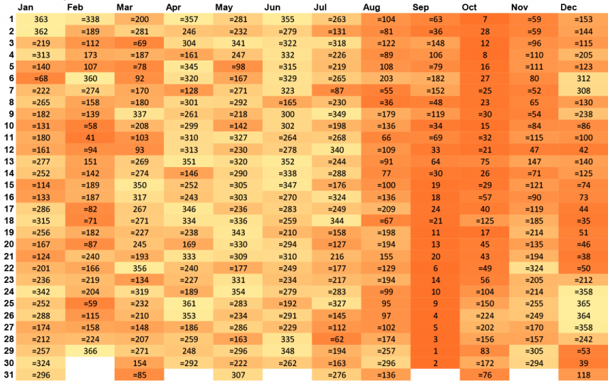

## More advantages of the simulation

Most common birthdays in England and Wales 1995-2014, [www.ons.gov.uk](https://www.ons.gov.uk/peoplepopulationandcommunity/birthsdeathsandmarriages/livebirths/bulletins/birthsummarytablesenglandandwales/2015-07-15).

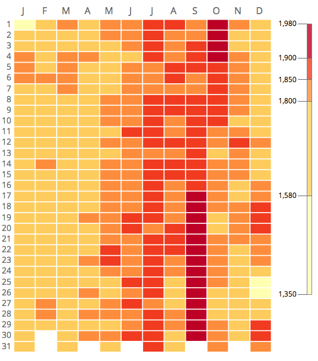

## More advantages of the simulation

Our simulation can easily be adapted to reflect the unequal distribution of birthdays in a certain country. The mathematics on the other hand would become enormously complex.

What will happen if we use realistic assumptions for the occurences of birthdays on different calendar days? Would the results change a lot?

## More advantages of the simulation

```r
EngWal <- read.csv("EnglandWalesBirthdays.csv")

nbr_students <- 50
nbr_same <- 4
numTrials <- 10000
numHits <- 0

for (i in 1:numTrials) {
  birthdays <- sample(1:366, size =  nbr_students, replace = TRUE, prob = EngWal$X2016 )
  numHits <- numHits + (max(table(birthdays)) >= nbr_same)
}
numHits/numTrials
```

```
## [1] 0.0046
```

## More advantages of the simulation

It seems our toy model simulation was already a pretty good reflection of reality, in which birthdays are not distributed equally but nevertheless fairly evenly.

While sometimes nuance is important, often simplifying assumptions are very reasonable.

## Activity II

## Introduction

- In the birthday problem activity we have infered information about a population (all classes of 20 students) by examining a sample of certain size.
- The sample has to be random, otherwise there is no reason to expect it will have similar properties as the population. Still, by chance alone the sample will differ, to a greater or lesser extend, from the population.

## Introduction

- In this activity, we have access to the entire population. This is rarely the case in real life.
- Gathering information on an entire population is often extremely costly or even impossible.
- Because of this, we often take a small sample of the population and use it to make educated guesses about the characteristics of the population under study.
- To illustrate this, let’s take as our population a data set of temperatures.

## Data set

- Download the data frame `temperatures.csv` from the US Centre for Environmental Information provided on Canvas and do some preliminary data exploration.
- Visualize the temperature data and describe it. What are its mean and standard deviation?

## Data set

The data set contains daily temperatures for 21 US cities from 1961 - 2015.

```r
pop <- read.csv("temperatures.csv")
unique(pop$CITY)
```

```
##  [1] "SEATTLE"       "SAN DIEGO"     "PHILADELPHIA"  "PHOENIX"
##  [5] "LAS VEGAS"     "CHARLOTTE"     "DALLAS"        "BALTIMORE"
##  [9] "SAN JUAN"      "LOS ANGELES"   "MIAMI"         "NEW ORLEANS"
## [13] "ALBUQUERQUE"   "PORTLAND"      "BOSTON"        "SAN FRANCISCO"
## [17] "TAMPA"         "NEW YORK"      "DETROIT"       "ST LOUIS"
## [21] "CHICAGO"
```

We’re interested in the *population* of daily temperatures across 21 cities. A contrived population? Yes, but it’s important to think about the relationship of samples (and statistics) and populations (and parameters).

## Data set

The data set is quite large and, given the geographic size of the US, temperatures can differ a lot.

```r
length(pop$CITY)
```

```
## [1] 421848
```

For convenience let’s assign

```r
pop <- pop$TEMP
```

## Data set

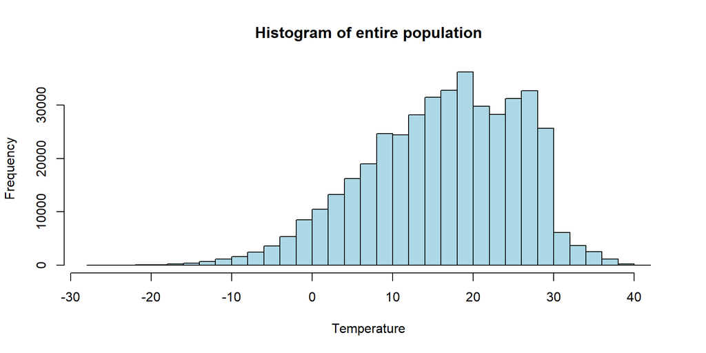

```r
hist(pop, breaks = 40, col = "lightblue",
     main="Histogram of entire population", xlab = "Temperature")
```

## Data set

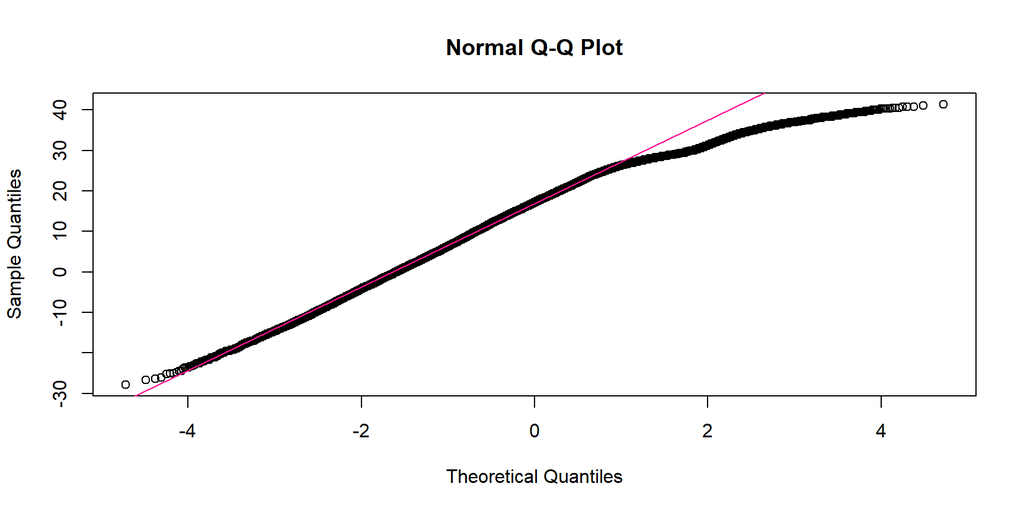

```r
qqnorm(pop)
qqline(pop, col = "deeppink")
```

## Estimating the population mean

The population mean \(\mu\) and population standard deviation \(\sigma\) are

```r
mu <- mean(pop)
mu
```

```
## [1] 16.29877
```

```r
sigma <- sd(pop)
sigma
```

```
## [1] 9.43757
```

## Estimating the population mean

- Now, draw a simple random sample of 100 temperatures only.
- Plot your sample next to the population and calculate the mean of your sample.
- Compare both with your teammates.

## Estimating the population mean

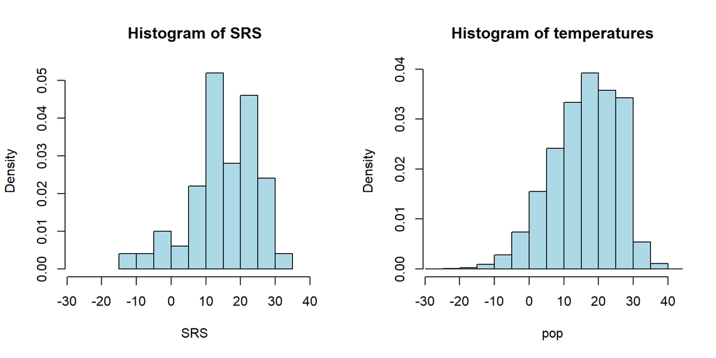

```r
SRS <- sample(pop, size = 100, replace = FALSE)
par(mfrow=c(1,2))
hist(SRS, col="lightblue", xlim=range(pop), freq=FALSE)
hist(pop,col="lightblue", main="Histogram of temperatures", xlim=range(pop), freq=FALSE)
```

```r
par(mfrow=c(1,1))
```

## Estimating the population mean

- Generally, the sample will have similar characteristics as the population, like skew to the left. But it really depends on your particular sample!
- With a sample size of **only** 100 out of over 400,000 data points, the mean and standard deviation of the sample are actually close to \(\mu\) and \(\sigma\).

```r
mean(SRS)
```

```
## [1] 15.529
```

```r
sd(SRS)
```

```
## [1] 9.440192
```

## Estimating the population mean

Was that just luck or can we expect that?

We noted that everyone who took a sample of size 100 got a different sample mean. How much variability should we expect when estimating the population mean repeatedly from samples of size 100?

- Draw 1000 samples of size 100. The mean of each sample will be different. Draw a histogram of all the sample means.
- What do you observe from the histogram of those sample means? Around what value is it centred? What is its variability?

## Estimating the population mean

We use a `for`-loop to draw 1000 random samples of size 100 and store the resulting means.

```r
trials    <- 1000
estimates <- numeric(trials)

for (i in 1:trials) {
  SRS <- sample(pop, size = 100, replace = FALSE)
  estimates[i] <- mean(SRS)
}
```

## Estimating the population mean

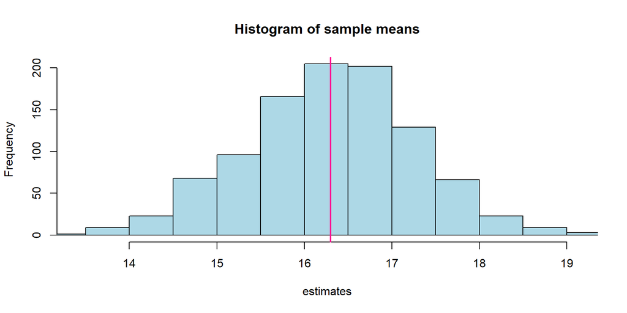

```r
hist(estimates, col="lightblue", breaks=20, xlim=range(estimates),
     main="Histogram of sample means")
abline(v = mu, lwd = 2, col = "deeppink")
```

## Estimating the population mean

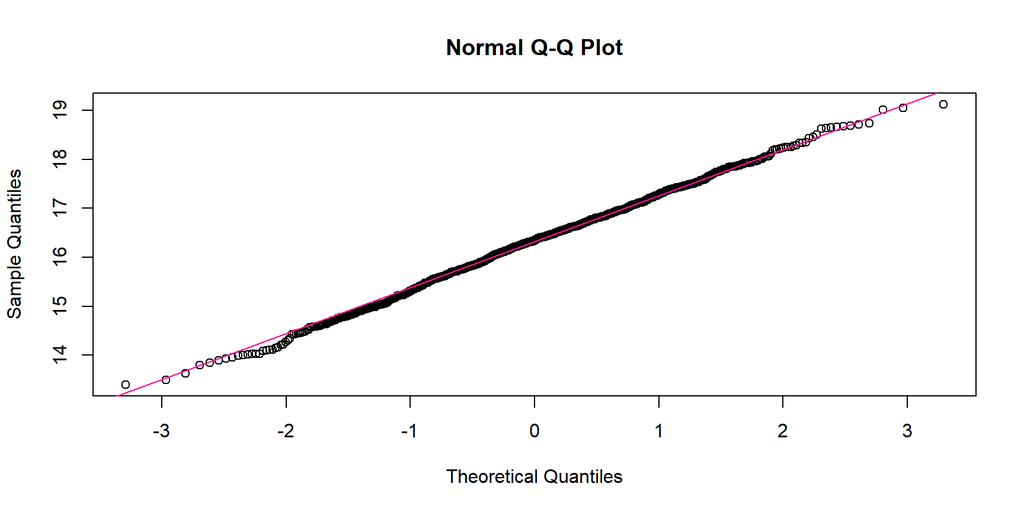

```r
qqnorm(estimates)
qqline(estimates, col="deeppink")
```

## Estimating the population mean

The histogram of the sample means looks like a normal distribution, centred around the true population mean.

```r
mean(estimates)
```

```
## [1] 16.30917
```

```r
mu
```

```
## [1] 16.29877
```

## Standard deviation of the sample means

The standard deviation of the sample means is

```r
sd(estimates)
```

```
## [1] 0.9694474
```

## Standard deviation of the sample means

Will doing more trials (i.e. collecting more sample means) change the standard deviation of the sample means?

- What would you expect? Discuss in your team first.
- Then just try by increasing the number of trials to 2000.

## Standard deviation of the sample means

```r
trials <- 2000
estimates_more_trials <-numeric(trials)

for (i in 1:trials) {
  SRS <- sample(pop, size = 100, replace = FALSE)
  estimates_more_trials[i] <- mean(SRS)
}
```

## Standard deviation of the sample means

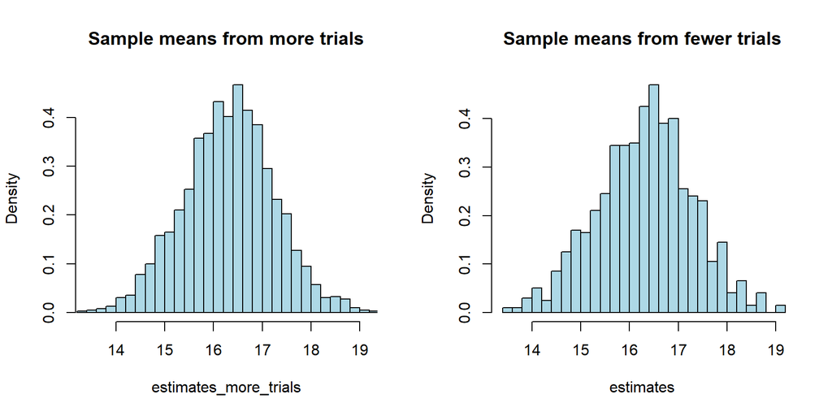

```r
par(mfrow=c(1,2))
hist(estimates_more_trials, breaks=40, col="lightblue",
     main="Sample means from more trials", xlim=range(estimates), freq = FALSE)
hist(estimates, breaks=40, col="lightblue", main="Sample means from fewer trials",
     xlim=range(estimates), freq = FALSE)
```

```r
par(mfrow=c(1,1))
```

## Standard deviation of the sample means

When taking more trials the standard deviation barely changed.

Will taking bigger sample sizes make the standard deviation of the sample means drop?

Go back to 1000 trials, but this time increase the sample size.

## Standard deviation of the sample means

```r
trials <- 1000
estimates_lss <-numeric(trials)

for (i in 1:trials) {
  SRS <- sample(pop, size = 500, replace = FALSE)
  estimates_lss[i] <- mean(SRS)
}
```

## Standard deviation of the sample means

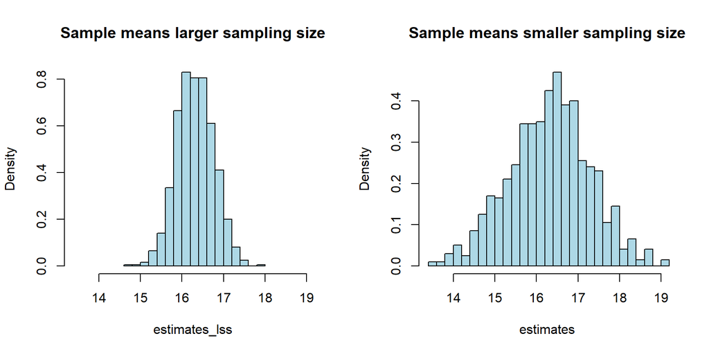

```r
par(mfrow=c(1,2))
hist(estimates_lss, breaks=20, col="lightblue",
     xlim=range(estimates), freq=FALSE, main="Sample means larger sampling size")
hist(estimates, breaks=40, col="lightblue", xlim=range(estimates), freq=FALSE, main="Sample means smaller sampling size")
```

```r
par(mfrow=c(1,1))
```

## Standard deviation of the sample means

Even going from sample size 100 to sample size 500 notably decreases the standard deviation, i.e. the spread of the histogram of the sample means.

- Is having a narrower distribution of sample means useful? Discuss with your team.

## Sampling variability - discussion

- If we repeatedly choose samples from the population, the sample mean will take different values in different samples.
- Simple idea: if we repeat sampling many times and the mean does not change substantially (i.e. if we get similar answers each time), our estimates are fairly reliable.

## Sampling variability - discussion

- For larger sample size, the estimates tend to get better. Not every time though, since there is sampling variability.
- On the other hand, the standard deviation of the distribution of sample means does get smaller with larger sample size.
- Important is not that we happen to get a better estimate when we increase sample size, but that the chance to be closer to the true mean of the population is higher.
- The distribution of sample means tends towards a normal distribution. We come back to this point on Thursday. (But if this is so and if we knew its standard deviation we could use the 68-95-99 rule to say e.g. that there is a 95% chance of the mean estimated from a sample to lie withing 2 standard deviations of the truth.)

## Standard deviation of the sample means - discussion

This sounds great! But is it practical?

## Standard error of the means

We observed that the standard deviation of the sample means decreased with the sample size.

- Check from the estimates you got for sample size \(n=100\) that it differs by roughly a factor of \(\sqrt{100}\) from the population standard deviation.

## Standard error of the means

```r
sd(pop)
```

```
## [1] 9.43757
```

For samples of size \(n=100\) we found

```r
sd(estimates)
```

```
## [1] 0.9694474
```

which differs by a factor of \(\sqrt{100}\).

The approximation \(\sigma/\sqrt{n}\) is called the *standard error* of the means.

## Discussion

What we found so far is not only true for the temperatures in the US but much more generally.

Moral: The larger \(n\) is, the *smaller* is the standard deviation of the distribution of sample means and the *closer* the sample mean is likely to be to the population mean.

## Remark

But wait, isn’t there another catch?

To know \(\sigma/\sqrt{n}\) in order to be able to judge of the accuracy we can expect when calculating the mean from one sample of size \(n\) we would need to know the entire population! And if we knew that we wouldn’t need to sample in the first place!

Well, sometimes \(\sigma\) is actually known (e.g. from other studies about similar populations). If \(\sigma\) is unknown people will use an approximation. Can you think of any?

## Recap and preview

## Learning goals

In today’s activities we

- became more proficient with using the R function `sample` and created `for` loops,
- used a simulation to make inferences about a population and answer “What if …?” questions.
- saw how the distribution of the population, sample, and the sample statistic (today we looked at the mean) differ.
- saw how sample size affects sampling variability and how the latter may be used to quantify the accuracy of our estimate.

## Preview

Next class we will

- explore how the shape of the population distribution influences what can be considered a *sufficiently large* sample size,
- check what happens when estimating other statistics than the mean,
- discuss different sampling schemes beyond simple randomized sampling.